# Phase pickers on three sequences outside the United States

The global campaign will run one PhaseNet weight set over every network EarthScope holds, most of it outside the United States and Japan. The fine-tuned `quakescope2026` was meant to be the more general of the two candidates; the western-states benchmark says its `jma_wc` parent still recovers more arrivals. Neither of those tests left the United States. This one does.

Three sequences, each with the network operator's own analyst picks published through an FDSN event service, chosen for large magnitude, a dense reviewed aftershock catalogue in the hours after the mainshock, and open waveforms.

[output not shown]

Kaiser et al. (2017, *SRL* 88, doi:10.1785/0220170018) is the seismological report for Kaikōura and Lanza et al. (2019, *GRL* 46, doi:10.1029/2019GL082780) relocated its aftershocks. Chiaraluce et al. (2017, *SRL* 88, doi:10.1785/0220160221) describe the central Italy sequence; Michele et al. (2020, *Sci. Rep.* 10, doi:10.1038/s41598-019-43393-2) hand-picked its early aftershocks. Karakostas et al. (2021, *Bull. Geol. Soc. Greece* 58) and Kassaras et al. (2022, *J. Geodyn.* 150, doi:10.1016/j.jog.2022.101898) analyse the Thessaly doublet. None of those papers' own pick files is used here: the reference is the operator's routine bulletin, harvested live, which is what a global campaign will be judged against.

### Weight sets

The same four as the US comparison, so the two reports read together.

| `quakescope2026` | the v7 fine-tune, the production candidate |
| --- | --- |
| `jma_wc` | the SeisBench Japanese model v7 was fine-tuned from, the baseline that matters |
| `original` | Zhu & Beroza (2019), the published reference |
| `instance` | trained on the Italian INSTANCE dataset: in-domain for Norcia, which makes it the control there |

### How it is scored

The method is the one in `phasenet_sequence_comparison.ipynb`: an aftershock window starting ten minutes after the mainshock, six stations, every model on identical waveforms, recall against **manual** analyst picks within 0.5 s. Recall is the metric; precision is not computed, because an aftershock catalogue is not exhaustive and an unmatched model pick may be an arrival nobody had time to mark. Section 7 holds the pick budget fixed rather than the threshold, which the US comparison showed is the only fair way to rank weight sets whose probabilities sit on different scales.

Two things differ from the US notebook. Stations are chosen by **where the analysts' picks are**, not by distance: nearest-first at Kaikōura would put the single close station in and leave the reference thin. And there is no curated event list, because none of these operators serves a revisable catalogue for a closed sequence in the way ComCat does; the event set is pinned instead by caching the harvest beside the notebook, so a re-run scores against the same picks.

### Where the picks come from, and why it is three different queries

Every operator publishes analyst arrivals through an FDSN event service, and every one does it differently. GeoNet rejects `includearrivals` outright but carries picks and arrivals in the per-event QuakeML, so each event is fetched by id. INGV accepts `includearrivals` only with an `eventid`, so it is the same loop. NOA answers region queries with arrivals in one go but refuses anything larger than about an hour of a busy sequence, so the window is asked for in hourly pieces. Section 4a reports what each service's QuakeML actually says about its picks.

```python
import io, json, time
from collections import Counter, defaultdict
from pathlib import Path

import boto3
import matplotlib.pyplot as plt
import numpy as np
import obspy
import pandas as pd
import seisbench.models as sbm
from obspy import UTCDateTime
from obspy.clients.fdsn import Client
from obspy.clients.fdsn.header import FDSNException
from obspy.geodetics import locations2degrees

%matplotlib inline
```

## 1. Configuration

```python
# Three sequences. `radius` bounds both the event harvest and the station search;
# `min_mag` is the operator's completeness in the hours after the mainshock,
# roughly - a lower floor only adds events with few picks.
SEQUENCES = {
    "Kaikoura 2016": dict(
        time=UTCDateTime("2016-11-13T11:02:56"), lat=-42.69, lon=173.02, mag=7.8,
        agency="GEONET", radius=2.0, min_mag=2.5, window_min=180,
        note="sparse permanent network; GeoNet reviews every located event",
    ),
    "Norcia 2016": dict(
        time=UTCDateTime("2016-10-30T06:40:18"), lat=42.83, lon=13.11, mag=6.5,
        agency="INGV", radius=0.8, min_mag=2.0, window_min=120,
        note="largest of the Amatrice-Visso-Norcia sequence; permanent plus temporary stations",
    ),
    "Thessaly 2021": dict(
        time=UTCDateTime("2021-03-03T10:16:08"), lat=39.75, lon=22.20, mag=6.3,
        agency="NOA", radius=1.0, min_mag=2.0, window_min=180,
        note="doublet with an M6.0 the next day; dense Greek network with a station 5 km away",
    ),
}

WEIGHTS = ["quakescope2026", "jma_wc", "original", "instance"]

WINDOW_START = 600        # s after the origin: past the mainshock coda
ORIGIN_LEAD = 180         # s: an origin this far before the window can still put arrivals in it
N_STATIONS = 6
CHANNEL_PREFERENCE = ["HH", "EH", "BH"]

DETECT_FLOOR = 0.02       # run once low, threshold offline
REPORT_THRESHOLD = 0.3
THRESHOLD_SWEEP = [0.05, 0.1, 0.15, 0.2, 0.3, 0.4, 0.5, 0.6, 0.7]
MATCH_TOL = 0.5           # s, an analyst pick counts as recovered within this

CACHE = Path("global_sequences_cache")   # gitignored: harvested picks, so the reference is pinned
CACHE.mkdir(exist_ok=True)

COLORS = ["#2a78d6", "#eb6834", "#1baf7a", "#eda100"]
C_P, C_S = "#2a78d6", "#eb6834"
plt.rcParams.update({"figure.dpi": 110, "axes.grid": True, "grid.alpha": 0.25,
                     "grid.linewidth": 0.5, "axes.axisbelow": True})
```

## 2. Data access

Waveforms and picks both come from the operator's FDSN services, routed by agency. Nothing here touches the campaign's S3 readers; section 8 checks whether the campaign has reached these networks yet.

```python
_clients = {}


def client_for(agency):
    if agency not in _clients:
        _clients[agency] = Client(agency, timeout=300)
    return _clients[agency]


def _event_id(ev):
    rid = str(ev.resource_id.id)
    return rid.split("eventId=")[-1].split("eventid=")[-1].split("/")[-1]


def _pick_rows(ev, label):
    """One row per arrival of the preferred origin, with the pick's own metadata."""
    origin = ev.preferred_origin() or (ev.origins[0] if ev.origins else None)
    if origin is None:
        return []
    mag = ev.preferred_magnitude() or (ev.magnitudes[0] if ev.magnitudes else None)
    by_id = {p.resource_id.id: p for p in ev.picks}
    rows = []
    for arr in origin.arrivals:
        pick = by_id.get(arr.pick_id.id)
        if pick is None or not arr.phase:
            continue
        phase = arr.phase[0].upper()
        if phase not in ("P", "S"):
            continue
        w = pick.waveform_id
        rows.append(dict(
            sequence=label, event=_event_id(ev), origin=origin.time.datetime,
            mag=mag.mag if mag else np.nan,
            station=f"{w.network_code}.{w.station_code}", channel=w.channel_code or "",
            phase=phase, time=pick.time.datetime,
            mode=str(pick.evaluation_mode), status=str(pick.evaluation_status),
            method=str(pick.method_id.id).split("/")[-1] if pick.method_id else "",
            agency=pick.creation_info.agency_id if pick.creation_info else "",
            time_weight=arr.time_weight if arr.time_weight is not None else np.nan,
            onset=str(pick.onset), uncertainty=pick.time_errors.uncertainty
            if pick.time_errors and pick.time_errors.uncertainty is not None else np.nan,
        ))
    return rows


def harvest(label, seq, t0, t1):
    """Every arrival the operator publishes for events in the window, all stations.

    Cached beside the notebook. The event services serve a revisable catalogue,
    so the cache is what pins the reference between runs - delete it to re-harvest.
    """
    cache = CACHE / f"{label.replace(' ', '_')}_picks.parquet"
    if cache.exists():
        return pd.read_parquet(cache)
    client = client_for(seq["agency"])
    region = dict(latitude=seq["lat"], longitude=seq["lon"], maxradius=seq["radius"],
                  minmagnitude=seq["min_mag"])
    rows, seen = [], set()
    t_start = time.time()
    if seq["agency"] == "NOA":
        # region queries carry arrivals, but only for about an hour of a busy
        # sequence at a time; split further if the service still refuses
        edges = np.arange(float(t0 - ORIGIN_LEAD), float(t1) + 1, 3600.0)
        pieces = [(UTCDateTime(a), UTCDateTime(min(a + 3600.0, float(t1)))) for a in edges if a < float(t1)]
        while pieces:
            a, b = pieces.pop(0)
            try:
                cat = client.get_events(starttime=a, endtime=b, includearrivals=True, **region)
            except FDSNException as exc:
                if "413" in str(exc) or "too much" in str(exc).lower():
                    m = a + (b - a) / 2
                    pieces = [(a, m), (m, b)] + pieces
                    continue
                if "204" in str(exc) or "No data" in str(exc):
                    continue
                raise
            for ev in cat:
                if _event_id(ev) in seen:
                    continue
                seen.add(_event_id(ev)); rows += _pick_rows(ev, label)
    else:
        cat = client.get_events(starttime=t0 - ORIGIN_LEAD, endtime=t1, **region)
        print(f"    {seq['agency']}: {len(cat)} events, fetching each one's arrivals", flush=True)
        for ev in cat:
            eid = _event_id(ev)
            try:
                if seq["agency"] == "INGV":
                    full = client.get_events(eventid=eid, includearrivals=True)
                else:                                   # GeoNet: the per-event QuakeML carries picks
                    full = client.get_events(eventid=eid)
            except FDSNException:
                continue
            for e in full:
                rows += _pick_rows(e, label)
    df = pd.DataFrame(rows)
    if len(df):
        df["origin"] = pd.to_datetime(df.origin, utc=True)
        df["time"] = pd.to_datetime(df.time, utc=True)
    df.to_parquet(cache)
    print(f"    harvested {len(df)} arrivals from {df.event.nunique() if len(df) else 0} events "
          f"in {time.time() - t_start:.0f} s")
    return df


def station_table(seq, picks, t0, t1):
    """Candidate stations within the radius with a pickable band, and how many
    manual picks the analysts made on each inside the window."""
    inv = client_for(seq["agency"]).get_stations(
        latitude=seq["lat"], longitude=seq["lon"], maxradius=seq["radius"],
        channel="HH?,EH?,BH?", starttime=t0, endtime=t1, level="channel")
    rows = []
    lo, hi = pd.Timestamp(t0.datetime, tz="UTC"), pd.Timestamp(t1.datetime, tz="UTC")
    inwin = picks[(picks["time"] >= lo) & (picks["time"] <= hi) & (picks["mode"] == "manual")]
    counts = inwin.groupby(["station", "phase"]).size().unstack(fill_value=0)
    for net in inv:
        for sta in net:
            bands = {ch.code[:2]: ch.sample_rate for ch in sta}
            band = next((b for b in CHANNEL_PREFERENCE if b in bands), None)
            if band is None:
                continue
            key = f"{net.code}.{sta.code}"
            rows.append(dict(station=key, band=band, rate=bands[band],
                             km=locations2degrees(seq["lat"], seq["lon"], sta.latitude, sta.longitude) * 111.19,
                             P=int(counts.loc[key, "P"]) if key in counts.index and "P" in counts else 0,
                             S=int(counts.loc[key, "S"]) if key in counts.index and "S" in counts else 0))
    t = pd.DataFrame(rows).drop_duplicates("station")
    t["picks"] = t.P + t.S
    return t.sort_values(["picks", "km"], ascending=[False, True]).reset_index(drop=True)


def fetch_station(agency, key, band, t0, t1):
    net, sta = key.split(".")
    try:
        st = client_for(agency).get_waveforms(net, sta, "*", band + "?", t0, t1)
    except FDSNException:
        return None
    st.merge(fill_value=0)
    if len(st) < 3:
        return None
    expected = (t1 - t0) * st[0].stats.sampling_rate
    if st[0].stats.npts < 0.5 * expected:
        return None
    return st


def select_and_fetch(label, seq, picks, t0, t1):
    """The N_STATIONS richest-in-picks stations that actually return the window."""
    table = station_table(seq, picks, t0, t1)
    streams, rates, chosen = {}, {}, []
    for r in table.itertuples():
        if len(streams) >= N_STATIONS:
            break
        st = fetch_station(seq["agency"], r.station, r.band, t0, t1)
        if st is None:
            continue
        streams[r.station] = st
        rates[r.station] = st[0].stats.sampling_rate
        chosen.append(r.Index)
    return streams, rates, table, chosen


def reference_from(picks, stations, t0, t1):
    """Manual picks on the chosen stations inside the window, keyed (station, phase),
    duplicates across events collapsed at MATCH_TOL."""
    lo, hi = pd.Timestamp(t0.datetime, tz="UTC"), pd.Timestamp(t1.datetime, tz="UTC")
    sel = picks[(picks["time"] >= lo) & (picks["time"] <= hi) & (picks["mode"] == "manual")
                & picks.station.isin(stations)]
    out = {}
    for (sta, pha), g in sel.groupby(["station", "phase"]):
        times, kept = sorted(UTCDateTime(t) for t in g["time"]), []
        for t in times:
            if not kept or t - kept[-1] > MATCH_TOL:
                kept.append(t)
        out[(sta, pha)] = kept
    return out


def at_threshold(store, thr):
    return {k: sorted(t for t, v in vals if v >= thr) for k, vals in store.items()}


def match(reference, candidate, tol=MATCH_TOL):
    """Greedy nearest match; each candidate pick is consumed at most once."""
    used, residuals = set(), []
    for a in reference:
        best_i = best_d = None
        for i, m in enumerate(candidate):
            if i in used:
                continue
            d = m - a
            if abs(d) <= tol and (best_d is None or abs(d) < abs(best_d)):
                best_i, best_d = i, d
        if best_i is not None:
            used.add(best_i)
            residuals.append(best_d)
    return residuals, len(candidate) - len(used)
```

## 3. Load the weight sets

```python
available = sbm.PhaseNet.list_pretrained()
models = {}
for name in WEIGHTS:
    if name not in available:
        print(f"{name:<16} not installed - skipping")
        continue
    try:
        models[name] = sbm.PhaseNet.from_pretrained(name)
        print(f"{name:<16} loaded")
    except Exception as exc:
        print(f"{name:<16} could not load ({type(exc).__name__}) - skipping")
if not models:
    raise RuntimeError("no weight sets available")
names = list(models)
```

```
quakescope2026   loaded
jma_wc           loaded
original         loaded
instance         loaded
```

## 4. Harvest, select, fetch, pick

The slow part is the harvest: one request per event for GeoNet and INGV. It runs once and is cached.

```python
results, harvested = {}, {}
for label, seq in SEQUENCES.items():
    print(f"{label} (M{seq['mag']}, {seq['note']})")
    t0 = seq["time"] + WINDOW_START
    t1 = t0 + seq["window_min"] * 60
    picks = harvest(label, seq, t0, t1)
    harvested[label] = picks
    if not len(picks):
        print("    no arrivals returned"); continue
    streams, rates, table, chosen = select_and_fetch(label, seq, picks, t0, t1)
    print(f"    {len(table)} candidate stations, {len(streams)} chosen by manual-pick count with data:")
    for i in chosen:
        r = table.loc[i]
        print(f"      {r.station:<10} {r.band}@{r.rate:g} Hz  {r.km:5.0f} km  {r.P:3d} P  {r.S:3d} S")
    skipped = [table.loc[i].station for i in table.index[:max(chosen) + 1] if i not in chosen] if chosen else []
    if skipped:
        print(f"    no data in the window: {', '.join(skipped)}")
    reference = reference_from(picks, list(streams), t0, t1)
    n_p = sum(len(v) for (_, ph), v in reference.items() if ph == "P")
    n_s = sum(len(v) for (_, ph), v in reference.items() if ph == "S")
    print(f"    reference: {n_p} P, {n_s} S manual picks on these stations")

    store = {}
    for name, model in models.items():
        per = defaultdict(list)
        for sta, st in streams.items():
            try:
                out = model.classify(st, P_threshold=DETECT_FLOOR, S_threshold=DETECT_FLOOR)
            except Exception as exc:
                print(f"    {name} {sta}: {type(exc).__name__}"); continue
            for p in out.picks:
                per[(sta, p.phase)].append((p.peak_time, float(p.peak_value)))
        store[name] = dict(per)
        tot = sum(1 for v in per.values() for t, q in v if q >= REPORT_THRESHOLD)
        print(f"    {name:<16} {tot} picks at {REPORT_THRESHOLD}")
    results[label] = dict(streams=streams, picks=store, reference=reference, t0=t0, t1=t1,
                          rates=rates, table=table, chosen=chosen)
    print()
```

```
Kaikoura 2016 (M7.8, sparse permanent network; GeoNet reviews every located event)
```

```
    27 candidate stations, 6 chosen by manual-pick count with data:
      NZ.BSWZ    EH@100 Hz    129 km   80 P   99 S
      NZ.TUWZ    EH@100 Hz    160 km   71 P   96 S
      NZ.TCW     EH@100 Hz    195 km   62 P   84 S
      NZ.THZ     HH@100 Hz    104 km   48 P   63 S
      NZ.CMWZ    EH@100 Hz    144 km   51 P   58 S
      NZ.KHZ     HH@100 Hz     52 km   45 P   58 S
    reference: 357 P, 458 S manual picks on these stations
```

```
    quakescope2026   2617 picks at 0.3
```

```
    jma_wc           2844 picks at 0.3
```

```
    original         3383 picks at 0.3
```

```
    instance         1522 picks at 0.3

Norcia 2016 (M6.5, largest of the Amatrice-Visso-Norcia sequence; permanent plus temporary stations)
```

```
    88 candidate stations, 6 chosen by manual-pick count with data:
      IV.GUMA    HH@100 Hz     32 km  134 P  127 S
      XO.AM05    EH@100 Hz     26 km  123 P  112 S
      IV.LNSS    HH@100 Hz     26 km  115 P  113 S
      IV.RM33    EH@100 Hz     37 km  111 P  103 S
      IV.CAMP    HH@100 Hz     41 km  113 P  100 S
      IV.MC2     EH@100 Hz     11 km  105 P  101 S
    reference: 701 P, 656 S manual picks on these stations
```

```
    quakescope2026   2408 picks at 0.3
```

```
    jma_wc           2537 picks at 0.3
```

```
    original         3446 picks at 0.3
```

```
    instance         1118 picks at 0.3

Thessaly 2021 (M6.3, doublet with an M6.0 the next day; dense Greek network with a station 5 km away)
```

```
    12 candidate stations, 6 chosen by manual-pick count with data:
      HL.THL     HH@100 Hz     26 km   73 P   73 S
      HT.TYRN    HH@100 Hz      5 km   64 P   64 S
      HT.LIT     HH@100 Hz     46 km   62 P   55 S
      HL.KZN     HH@100 Hz     71 km   66 P   51 S
      HT.AGG     HH@100 Hz     82 km   64 P   45 S
      HL.TETR    HH@100 Hz     91 km   66 P   43 S
    reference: 395 P, 331 S manual picks on these stations
```

```
    quakescope2026   2553 picks at 0.3
```

```
    jma_wc           2777 picks at 0.3
```

```
    original         3877 picks at 0.3
```

```
    instance         1454 picks at 0.3
```

## 4a. What the three services' QuakeML actually says

Inspected rather than assumed, as in the US notebook. `mode` is the pick's `evaluationMode`; `method` is whatever the pick's `methodID` ends in; `agency` is the pick's `creationInfo.agencyID`. Only `manual` picks enter the reference.

```python
rows = []
for label, df in harvested.items():
    if not len(df):
        continue
    res = results.get(label)
    lo, hi = pd.Timestamp(res["t0"].datetime, tz="UTC"), pd.Timestamp(res["t1"].datetime, tz="UTC")
    w = df[(df["time"] >= lo) & (df["time"] <= hi)]
    rows.append(dict(
        sequence=label, events=w.event.nunique(), arrivals=len(w),
        mode=dict(w["mode"].value_counts()), status=dict(w["status"].value_counts().head(3)),
        method=dict(w["method"].value_counts().head(3)), agency=dict(w["agency"].value_counts().head(2)),
        onset=dict(w["onset"].value_counts().head(3)),
        uncertainty_set=f"{w.uncertainty.notna().mean():.0%}",
        zero_weight=int((w.time_weight == 0).sum()),
    ))
prov = pd.DataFrame(rows).set_index("sequence")
with pd.option_context("display.max_colwidth", 80, "display.width", 200):
    print(prov.T.to_string())
```

```
sequence                               Kaikoura 2016                  Norcia 2016      Thessaly 2021
events                                           138                          150                 74
arrivals                                        7134                         8873               3570
mode             {'manual': 5308, 'automatic': 1826}             {'manual': 8873}   {'manual': 3570}
status                                {'None': 7134}               {'None': 8873}     {'None': 3570}
method                       {'': 5308, 'AIC': 1826}  {'query?methodID=11': 8873}         {'': 3570}
agency                    {'WEL(GNS_Primary)': 4806}              {'INGV ': 8873}  {'NOAreg1': 3570}
onset                                 {'None': 7134}       {'questionable': 8873}     {'None': 3570}
uncertainty_set                                   0%                         100%                 0%
zero_weight                                     1845                          617                 37
```

## 5. Recall against analyst picks

At the shared 0.3 threshold first, because that is how everyone reads a picker. Section 7 is the fair version.

```python
rows = []
for label, res in results.items():
    for name in names:
        view = at_threshold(res["picks"][name], REPORT_THRESHOLD)
        for phase in ("P", "S"):
            n_ref = n_hit = n_extra = 0; residuals = []
            for sta in res["streams"]:
                ref = res["reference"].get((sta, phase), [])
                got = view.get((sta, phase), [])
                r, extra = match(ref, got)
                n_ref += len(ref); n_hit += len(r); n_extra += extra; residuals += r
            if n_ref == 0:
                continue
            rows.append(dict(sequence=label, weights=name, phase=phase, analyst=n_ref, matched=n_hit,
                             recall=round(n_hit / n_ref, 3),
                             MAE=round(float(np.mean(np.abs(residuals))), 3) if residuals else np.nan,
                             bias=round(float(np.median(residuals)), 3) if residuals else np.nan,
                             extra=n_extra))
bench = pd.DataFrame(rows)
print(bench.to_string(index=False))
for phase in ("P", "S"):
    piv = bench[bench.phase == phase].pivot(index="sequence", columns="weights", values="recall")
    print(f"\n{phase} recall at {REPORT_THRESHOLD}")
    print(piv.reindex(columns=[n for n in names if n in piv.columns]).to_string())
```

```
     sequence        weights phase  analyst  matched  recall   MAE   bias  extra
Kaikoura 2016 quakescope2026     P      357      236   0.661 0.139  0.077   1390
Kaikoura 2016 quakescope2026     S      458      230   0.502 0.162  0.034    761
Kaikoura 2016         jma_wc     P      357      251   0.703 0.139  0.062   1564
Kaikoura 2016         jma_wc     S      458      238   0.520 0.163 -0.026    791
Kaikoura 2016       original     P      357      235   0.658 0.154  0.100   1410
Kaikoura 2016       original     S      458      323   0.705 0.177  0.089   1415
Kaikoura 2016       instance     P      357      230   0.644 0.141  0.044    680
Kaikoura 2016       instance     S      458      244   0.533 0.166 -0.039    368
  Norcia 2016 quakescope2026     P      701      535   0.763 0.049  0.000    725
  Norcia 2016 quakescope2026     S      656      488   0.744 0.064  0.010    660
  Norcia 2016         jma_wc     P      701      557   0.795 0.048  0.000    786
  Norcia 2016         jma_wc     S      656      510   0.777 0.069 -0.020    684
  Norcia 2016       original     P      701      516   0.736 0.057  0.028   1008
  Norcia 2016       original     S      656      595   0.907 0.085  0.050   1327
  Norcia 2016       instance     P      701      433   0.618 0.056 -0.010    130
  Norcia 2016       instance     S      656      439   0.669 0.076 -0.040    116
Thessaly 2021 quakescope2026     P      395      284   0.719 0.129  0.021   1355
Thessaly 2021 quakescope2026     S      331      129   0.390 0.129  0.034    785
Thessaly 2021         jma_wc     P      395      295   0.747 0.135  0.021   1431
Thessaly 2021         jma_wc     S      331      133   0.402 0.132  0.024    918
Thessaly 2021       original     P      395      286   0.724 0.139  0.053   1552
Thessaly 2021       original     S      331      142   0.429 0.146  0.072   1897
Thessaly 2021       instance     P      395      286   0.724 0.139  0.009    646
Thessaly 2021       instance     S      331      130   0.393 0.148 -0.021    392

P recall at 0.3
weights        quakescope2026  jma_wc  original  instance
sequence
Kaikoura 2016           0.661   0.703     0.658     0.644
Norcia 2016             0.763   0.795     0.736     0.618
Thessaly 2021           0.719   0.747     0.724     0.724

S recall at 0.3
weights        quakescope2026  jma_wc  original  instance
sequence
Kaikoura 2016           0.502   0.520     0.705     0.533
Norcia 2016             0.744   0.777     0.907     0.669
Thessaly 2021           0.390   0.402     0.429     0.393
```

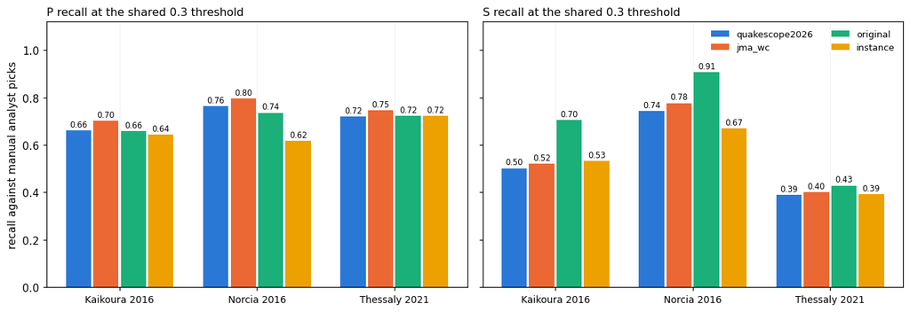

```python
seqs = [s for s in SEQUENCES if s in set(bench.sequence)]
fig, axes = plt.subplots(1, 2, figsize=(12, 4.2), sharey=True)
for ax, phase in zip(axes, ("P", "S")):
    sub = bench[bench.phase == phase]
    width = 0.8 / max(len(names), 1)
    for i, name in enumerate(names):
        xs, vals = [], []
        for j, s in enumerate(seqs):
            row = sub[(sub.sequence == s) & (sub.weights == name)]
            if len(row):
                xs.append(j + (i - (len(names) - 1) / 2) * width); vals.append(float(row.recall.iloc[0]))
        ax.bar(xs, vals, width=width * 0.92, color=COLORS[i], label=name)
        for x, v in zip(xs, vals):
            ax.text(x, v + 0.015, f"{v:.2f}", ha="center", fontsize=7.5)
    ax.set_xticks(range(len(seqs))); ax.set_xticklabels(seqs, fontsize=9)
    ax.set_ylim(0, 1.12); ax.grid(axis="y")
    ax.set_title(f"{phase} recall at the shared {REPORT_THRESHOLD} threshold", fontsize=10.5, loc="left")
axes[0].set_ylabel("recall against manual analyst picks")
axes[1].legend(frameon=False, fontsize=8.5, ncol=2, loc="upper right")
fig.tight_layout(); plt.show()
```

## 6. Timing

The v7 fine-tune was selected for arrival-time precision, not for recall. If that carries outside the training domain it should show here as a tighter residual on the picks both weights find. The residual is model pick minus analyst pick on matched picks at the shared threshold, pooled over the three sequences; a positive median means the model picks late.

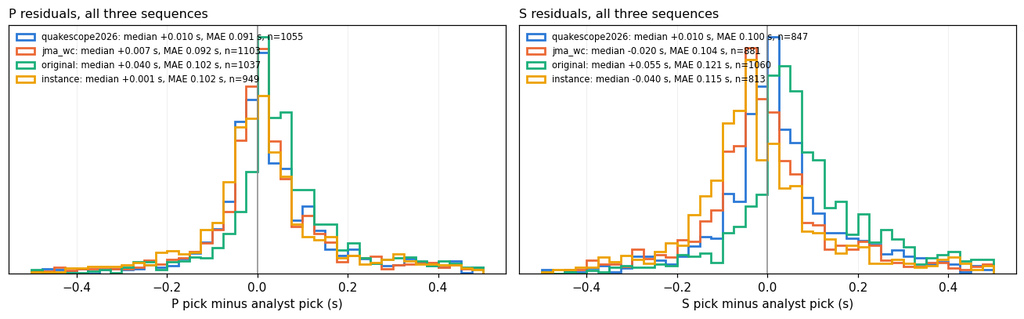

```
MAE (s) at the shared threshold, per sequence
weights              quakescope2026  jma_wc  original  instance
phase sequence
P     Kaikoura 2016           0.139   0.139     0.154     0.141
      Norcia 2016             0.049   0.048     0.057     0.056
      Thessaly 2021           0.129   0.135     0.139     0.139
S     Kaikoura 2016           0.162   0.163     0.177     0.166
      Norcia 2016             0.064   0.069     0.085     0.076
      Thessaly 2021           0.129   0.132     0.146     0.148
```

```python
fig, axes = plt.subplots(1, 2, figsize=(12, 3.8))
bins = np.arange(-MATCH_TOL, MATCH_TOL + 0.025, 0.025)
for ax, phase in zip(axes, ("P", "S")):
    for i, name in enumerate(names):
        res_all = []
        for label, res in results.items():
            view = at_threshold(res["picks"][name], REPORT_THRESHOLD)
            for sta in res["streams"]:
                r, _ = match(res["reference"].get((sta, phase), []), view.get((sta, phase), []))
                res_all += r
        if not res_all:
            continue
        res_all = np.array(res_all)
        ax.hist(res_all, bins=bins, histtype="step", lw=1.8, color=COLORS[i], density=True,
                label=f"{name}: median {np.median(res_all):+.3f} s, MAE {np.mean(np.abs(res_all)):.3f} s, n={len(res_all)}")
    ax.axvline(0, color="#8a8a8a", lw=1); ax.set_yticks([])
    ax.set_xlabel(f"{phase} pick minus analyst pick (s)")
    ax.set_title(f"{phase} residuals, all three sequences", fontsize=10.5, loc="left")
    ax.legend(frameon=False, fontsize=7.5, loc="upper left")
fig.tight_layout(); plt.show()

print("MAE (s) at the shared threshold, per sequence")
print(bench.pivot_table(index=["phase", "sequence"], columns="weights", values="MAE").reindex(columns=names).round(3).to_string())
```

## 7. Matched pick budgets

A threshold is not an operating point. Each model's probabilities sit on their own scale, so at a shared 0.3 one emits more picks than another and collects recall for it. Holding the number of picks emitted fixed and asking which weight set recovers more of the analyst catalogue is the comparison that survives a change of threshold, and it is what the US comparison found erased most of the apparent ranking there.

```python
sweep_rows = []
for label, res in results.items():
    for name in names:
        for thr in THRESHOLD_SWEEP:
            view = at_threshold(res["picks"][name], thr)
            for phase in ("P", "S"):
                hit = tot = emitted = 0
                for sta in res["streams"]:
                    ref = res["reference"].get((sta, phase), []); got = view.get((sta, phase), [])
                    r, _ = match(ref, got); hit += len(r); tot += len(ref); emitted += len(got)
                if tot < 20:
                    continue
                sweep_rows.append(dict(sequence=label, weights=name, phase=phase, thr=thr,
                                       recall=hit / tot, emitted=emitted))
sweep = pd.DataFrame(sweep_rows)


def matched_budget(sweep, phase, sequence, n_points=4):
    sub = sweep[(sweep.phase == phase) & (sweep.sequence == sequence)]
    present = [n for n in names if n in set(sub.weights)]
    if len(present) < 2:
        return None
    lo = max(sub[sub.weights == n].emitted.min() for n in present)
    hi = min(sub[sub.weights == n].emitted.max() for n in present)
    if not np.isfinite([lo, hi]).all() or hi <= lo:
        ceiling = min(present, key=lambda n: sub[sub.weights == n].emitted.max())
        print(f"{sequence} {phase}: no common budget - {ceiling} tops out at "
              f"{int(sub[sub.weights == ceiling].emitted.max())} picks, below where the others start.")
        return None
    rows = []
    for target in np.linspace(lo, hi, n_points):
        row = {"picks_emitted": int(round(target))}
        for n in present:
            d = sub[sub.weights == n].sort_values("emitted")
            row[n] = round(float(np.interp(target, d.emitted, d.recall)), 3)
        rows.append(row)
    return pd.DataFrame(rows)


budget_tables = {}
for phase in ("S", "P"):
    for sequence in SEQUENCES:
        tab = matched_budget(sweep, phase, sequence)
        if tab is None:
            continue
        budget_tables[(sequence, phase)] = tab
        print(f"{sequence} - {phase} recall at matched pick budgets"); print(tab.to_string(index=False)); print()
```

```
Kaikoura 2016 - S recall at matched pick budgets
 picks_emitted  quakescope2026  jma_wc  original  instance
           507           0.259   0.263     0.236     0.467
           771           0.377   0.382     0.359     0.609
          1034           0.516   0.522     0.488     0.697
          1298           0.603   0.621     0.598     0.738

Norcia 2016 - S recall at matched pick budgets
 picks_emitted  quakescope2026  jma_wc  original  instance
           816           0.591   0.613     0.556     0.813
           896           0.634   0.653     0.594     0.841
           975           0.668   0.686     0.631     0.858
          1055           0.703   0.719     0.668     0.875

Thessaly 2021 - S recall at matched pick budgets
 picks_emitted  quakescope2026  jma_wc  original  instance
           708           0.358   0.350     0.302     0.416
           945           0.392   0.386     0.344     0.433
          1181           0.410   0.413     0.373     0.456
          1418           0.428   0.432     0.397     0.474

Kaikoura 2016 - P recall at matched pick budgets
 picks_emitted  quakescope2026  jma_wc  original  instance
           756           0.407   0.439     0.409     0.580
          1061           0.504   0.546     0.539     0.669
          1367           0.608   0.624     0.611     0.719
          1672           0.667   0.681     0.660     0.739

Norcia 2016 - P recall at matched pick budgets
 picks_emitted  quakescope2026  jma_wc  original  instance
           691           0.557   0.578     0.534     0.706
           837           0.628   0.648     0.595     0.755
           982           0.691   0.705     0.646     0.785
          1128           0.736   0.751     0.680     0.807

Thessaly 2021 - P recall at matched pick budgets
 picks_emitted  quakescope2026  jma_wc  original  instance
          1014           0.573   0.612     0.529     0.730
          1227           0.636   0.669     0.613     0.748
          1439           0.683   0.705     0.666     0.760
          1652           0.720   0.736     0.693     0.762
```

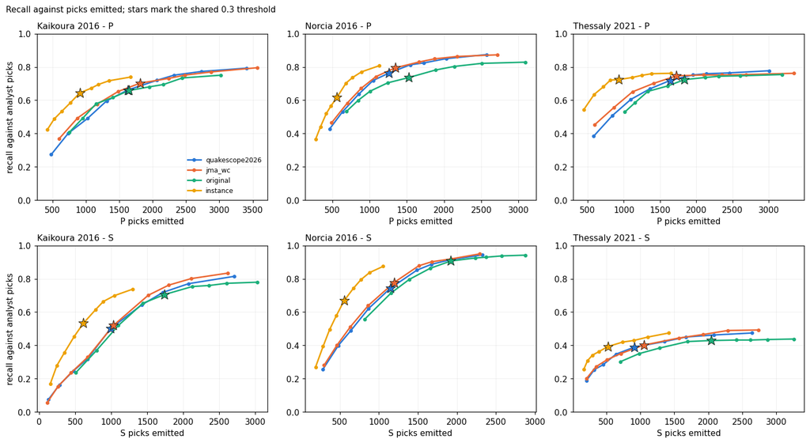

```
Picks emitted by threshold; the floor column is each model's ceiling
     sequence        weights  P@0.02  S@0.02  P@0.1  S@0.1  P@0.3  S@0.3
Kaikoura 2016 quakescope2026    4786    3682   2733   2072   1626    991
Kaikoura 2016         jma_wc    4855    3416   2880   2109   1815   1029
Kaikoura 2016       original    3942    3674   2445   2604   1645   1738
Kaikoura 2016       instance    2231    1644   1346   1042    910    612
  Norcia 2016 quakescope2026    3618    2837   2031   1917   1260   1148
  Norcia 2016         jma_wc    3667    2777   2173   1923   1343   1194
  Norcia 2016       original    4074    3312   2506   2574   1524   1922
  Norcia 2016       instance    1546    1321    890    878    563    555
Thessaly 2021 quakescope2026    4217    3449   2457   2077   1639    914
Thessaly 2021         jma_wc    4557    3460   2687   2287   1726   1051
Thessaly 2021       original    4135    3888   2603   2867   1838   2039
Thessaly 2021       instance    2117    1821   1382   1113    932    522
```

```python
seqs = [s for s in SEQUENCES if s in set(sweep.sequence)]
fig, axes = plt.subplots(2, len(seqs), figsize=(4.6 * len(seqs), 7.6), squeeze=False)
for row, phase in enumerate(("P", "S")):
    for ax, sequence in zip(axes[row], seqs):
        sub = sweep[(sweep.phase == phase) & (sweep.sequence == sequence)]
        for name, color in zip(names, COLORS):
            d = sub[sub.weights == name].sort_values("emitted")
            if not len(d):
                continue
            ax.plot(d.emitted, d.recall, marker="o", ms=3.5, lw=1.8, color=color, label=name)
            star = d[np.isclose(d.thr, REPORT_THRESHOLD)]
            if len(star):
                ax.plot(star.emitted, star.recall, marker="*", ms=13, color=color, mec="#16150f", mew=0.6, zorder=5)
        ax.set_title(f"{sequence} - {phase}", fontsize=10.5, loc="left")
        ax.set_xlabel(f"{phase} picks emitted"); ax.set_ylim(0, 1)
    axes[row][0].set_ylabel("recall against analyst picks")
axes[0][0].legend(frameon=False, fontsize=8)
fig.suptitle(f"Recall against picks emitted; stars mark the shared {REPORT_THRESHOLD} threshold",
             fontsize=10, x=0.01, ha="left")
fig.tight_layout(); plt.show()

sat_rows = []
for label, res in results.items():
    for name in names:
        row = {"sequence": label, "weights": name}
        for thr in (DETECT_FLOOR, 0.1, REPORT_THRESHOLD):
            view = at_threshold(res["picks"][name], thr)
            row[f"P@{thr}"] = sum(len(v) for (_, ph), v in view.items() if ph == "P")
            row[f"S@{thr}"] = sum(len(v) for (_, ph), v in view.items() if ph == "S")
        sat_rows.append(row)
print("Picks emitted by threshold; the floor column is each model's ceiling")
print(pd.DataFrame(sat_rows).to_string(index=False))
```

### The pair that matters: `quakescope2026` against `jma_wc`

One number per sequence and phase: the recall difference at a common budget, taken at the midpoint of the overlap. Positive favours the fine-tune.

```python
rows = []
for (sequence, phase), tab in budget_tables.items():
    if "quakescope2026" not in tab or "jma_wc" not in tab:
        continue
    mid = tab.iloc[len(tab) // 2]
    at_thr = bench[(bench.sequence == sequence) & (bench.phase == phase)].set_index("weights")
    rows.append(dict(sequence=sequence, phase=phase, budget=int(mid.picks_emitted),
                     quakescope2026=mid["quakescope2026"], jma_wc=mid["jma_wc"],
                     diff_at_budget=round(mid["quakescope2026"] - mid["jma_wc"], 3),
                     diff_at_thr=round(at_thr.loc["quakescope2026", "recall"] - at_thr.loc["jma_wc", "recall"], 3),
                     MAE_q26=at_thr.loc["quakescope2026", "MAE"], MAE_jma=at_thr.loc["jma_wc", "MAE"]))
pair = pd.DataFrame(rows).sort_values(["phase", "sequence"])
print(pair.to_string(index=False))
print(f"\nmean recall difference at matched budget: P {pair[pair.phase == 'P'].diff_at_budget.mean():+.3f}, "
      f"S {pair[pair.phase == 'S'].diff_at_budget.mean():+.3f}")
```

```
     sequence phase  budget  quakescope2026  jma_wc  diff_at_budget  diff_at_thr  MAE_q26  MAE_jma
Kaikoura 2016     P    1367           0.608   0.624          -0.016       -0.042    0.139    0.139
  Norcia 2016     P     982           0.691   0.705          -0.014       -0.032    0.049    0.048
Thessaly 2021     P    1439           0.683   0.705          -0.022       -0.028    0.129    0.135
Kaikoura 2016     S    1034           0.516   0.522          -0.006       -0.018    0.162    0.163
  Norcia 2016     S     975           0.668   0.686          -0.018       -0.033    0.064    0.069
Thessaly 2021     S    1181           0.410   0.413          -0.003       -0.012    0.129    0.132

mean recall difference at matched budget: P -0.017, S -0.009
```

### Export for the consolidated benchmark

Writes the tables above to `docs/benchmark/results/` so that `tutorials/benchmark_summary.ipynb` reads executed output.

```python
# Export the result tables for docs/benchmark/. The consolidated benchmark
# (tutorials/benchmark_summary.ipynb) reads these files rather than numbers
# transcribed from a rendered report, so every figure there traces to an
# executed cell here. Defensive on purpose: a missing table is reported, not fatal.
import datetime as _dt, json as _json
from pathlib import Path as _Path
import seisbench as _sb
_OUT = _Path("../docs/benchmark/results/global_sequences"); _OUT.mkdir(parents=True, exist_ok=True)
_written = []
def _export(name, obj):
    try:
        (obj.to_csv(_OUT / f"{name}.csv", index=isinstance(obj.index, pd.MultiIndex) or obj.index.name is not None)
         if hasattr(obj, "to_csv") else (_OUT / f"{name}.json").write_text(_json.dumps(obj, indent=1, default=str)))
        _written.append(name)
    except Exception as _exc:
        print(f"{name}: not exported ({type(_exc).__name__}: {_exc})")

_export("recall_at_threshold", bench)
_export("threshold_sweep", sweep)
_export("pair_v7_vs_jma", pair)
_export("reference_provenance", prov.reset_index())
# Raw picks, so every metric can be recomputed without re-running inference.
# One row per model pick at the detection floor with its peak confidence, and
# one per reference arrival. docs/benchmark/README.md scores these with
# sb_catalog.src.benchmark_metrics; keeping them means a new metric costs a
# read rather than ten minutes of inference.
_rows = []
for _label, _res in results.items():
    for _name, _store in _res["picks"].items():
        for (_sta, _pha), _v in _store.items():
            for _t, _q in _v:
                _rows.append(dict(sequence=_label, weights=_name, station=_sta, phase=_pha,
                                  time=pd.Timestamp(_t.datetime), conf=float(_q)))
_picks = pd.DataFrame(_rows)
_export("model_picks", _picks)

_rows = []
for _label, _res in results.items():
    for (_sta, _pha), _v in _res["reference"].items():
        for _t in _v:
            _rows.append(dict(sequence=_label, station=_sta, phase=_pha,
                              time=pd.Timestamp(_t.datetime)))
_ref = pd.DataFrame(_rows)
_export("reference_picks", _ref)
print(f"exported {len(_picks):,} model picks at the {DETECT_FLOOR} floor and {len(_ref):,} reference arrivals")

_meta = dict(notebook="phasenet_global_sequences.ipynb",
             executed=_dt.datetime.now(_dt.timezone.utc).isoformat(timespec="seconds"),
             seisbench=_sb.__version__, weights=WEIGHTS, report_threshold=REPORT_THRESHOLD,
             detect_floor=DETECT_FLOOR, match_tol_s=MATCH_TOL, window_start_s=WINDOW_START,
             n_stations=N_STATIONS,
             sequences={k: dict(time=str(v["time"]), mag=v["mag"], lat=v["lat"], lon=v["lon"],
                                agency=v["agency"], window_min=v["window_min"],
                                stations=sorted(results[k]["streams"]) if k in results else [])
                        for k, v in SEQUENCES.items()})
_export("meta", _meta)
print("wrote", ", ".join(_written), "to", _OUT)
```

```
exported 79,026 model picks at the 0.02 floor and 2,898 reference arrivals
wrote recall_at_threshold, threshold_sweep, pair_v7_vs_jma, reference_provenance, model_picks, reference_picks, meta to ../docs/benchmark/results/global_sequences
```

## 8. Where the global campaign stands on these networks

The campaign's station table already lists these operators' networks, and it will pick them with `jma_wc`. When it has, its stored picks can be scored here exactly as the OBS report scores the `obs` campaign. Until then this cell only says what is there.

```python
BUCKET, REGION, CAMPAIGN = "quakescope-picks-2026", "us-east-2", "global"
s3 = boto3.client("s3", region_name=REGION)
_pg = s3.get_paginator("list_objects_v2")
station_tbl = pd.read_parquet(io.BytesIO(s3.get_object(Bucket=BUCKET, Key=f"{CAMPAIGN}/stations.parquet")["Body"].read()))

for label, res in results.items():
    nets = sorted({s.split(".")[0] for s in res["streams"]})
    t0 = res["t0"]
    listed = station_tbl[station_tbl.network_code.isin(nets)]
    have = 0
    for net in nets:
        prefix = f"{CAMPAIGN}/picks/network={net}/year={t0.year}/month={t0.month:02d}/"
        have += sum(1 for page in _pg.paginate(Bucket=BUCKET, Prefix=prefix) for _ in page.get("Contents", []))
    print(f"{label:<14} networks {nets}: {len(listed)} stations in the campaign table, "
          f"{have} pick objects for {t0.year}-{t0.month:02d}"
          + ("" if have else " - not picked yet"))
```

```
Kaikoura 2016  networks ['NZ']: 1159 stations in the campaign table, 0 pick objects for 2016-11 - not picked yet
Norcia 2016    networks ['IV', 'XO']: 0 stations in the campaign table, 0 pick objects for 2016-10 - not picked yet
```

```
Thessaly 2021  networks ['HL', 'HT']: 10 stations in the campaign table, 0 pick objects for 2021-03 - not picked yet
```

## 9. What the picks look like

One record section per sequence from the model with the most picks at the reporting threshold, with the analyst's picks marked above the traces so the recall numbers can be checked by eye.

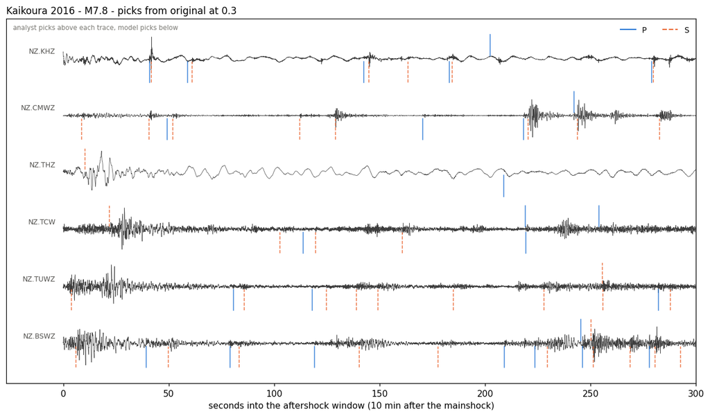

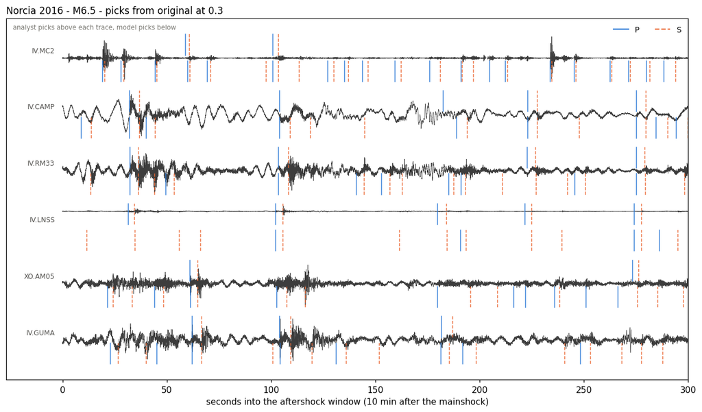

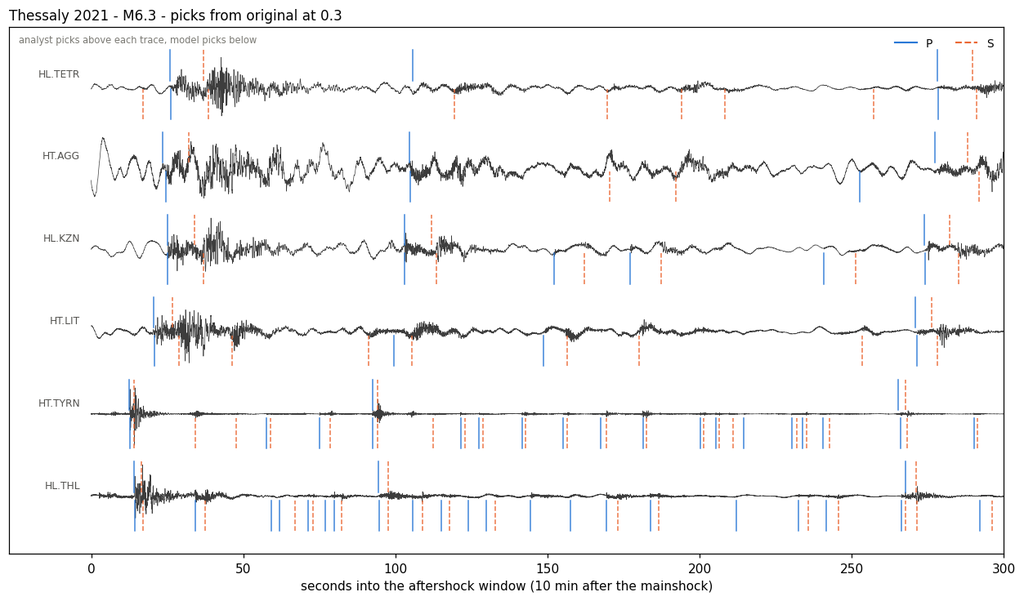

```python
def record_section(label, res, weight, span=300):
    seq = SEQUENCES[label]
    order = list(res["streams"])
    fig, ax = plt.subplots(figsize=(11.5, 0.9 * len(order) + 1.4))
    view = at_threshold(res["picks"][weight], REPORT_THRESHOLD)
    for row, sta in enumerate(order):
        tr = res["streams"][sta].select(component="Z")
        if not tr:
            continue
        tr = tr[0].copy(); tr.trim(res["t0"], res["t0"] + span)
        x = tr.data.astype(float); peak = np.abs(x).max()
        if peak > 0:
            x = x / peak * 0.38
        ax.plot(tr.times(), x + row, color="#3d3d3d", lw=0.45)
        ax.annotate(sta, (-span * 0.012, row + 0.1), fontsize=8, color="#52514e", ha="right")
        for phase, color, ls in (("P", C_P, "-"), ("S", C_S, "--")):
            for t in view.get((sta, phase), []):
                dt = t - res["t0"]
                if 0 <= dt <= span:
                    ax.plot([dt, dt], [row - 0.42, row - 0.05], color=color, lw=1.0, ls=ls, alpha=0.9)
            for t in res["reference"].get((sta, phase), []):
                dt = t - res["t0"]
                if 0 <= dt <= span:
                    ax.plot([dt, dt], [row + 0.05, row + 0.42], color=color, lw=1.0, ls=ls, alpha=0.9)
    handles = [plt.Line2D([], [], color=C_P, lw=1.4, label="P"), plt.Line2D([], [], color=C_S, lw=1.4, ls="--", label="S")]
    ax.legend(handles=handles, frameon=False, fontsize=9, ncol=2, loc="upper right")
    ax.text(0.01, 0.985, "analyst picks above each trace, model picks below", transform=ax.transAxes,
            ha="left", va="top", fontsize=7.5, color="#7a7973")
    ax.set_xlim(-span * 0.09, span); ax.set_ylim(-0.7, len(order) - 0.3); ax.set_yticks([])
    ax.set_xlabel(f"seconds into the aftershock window ({WINDOW_START // 60} min after the mainshock)")
    ax.set_title(f"{label} - M{seq['mag']} - picks from {weight} at {REPORT_THRESHOLD}", fontsize=11, loc="left")
    ax.grid(axis="x")
    fig.tight_layout()
    return fig


for label, res in results.items():
    best = max(res["picks"], key=lambda n: sum(1 for v in res["picks"][n].values() for t, q in v if q >= REPORT_THRESHOLD))
    record_section(label, res, best); plt.show()
```

## Reading the result

**Thessaly's S recall is capped near 0.5 for every weight at every budget.** Nothing on the sweep exceeds 0.49. A ceiling shared by four unrelated weight sets belongs to the reference or the data, not to a model: the NOA analysts pick S on stations 45–90 km out where every model finds the P and not the S. The cause is not identified here, and the number should not be quoted without that caveat.

**Provenance is uneven across operators, and it shapes the reference.** GeoNet's QuakeML carries a quarter of its picks as `automatic` from an AIC picker, which the reference excludes, and 1,845 arrivals with zero weight in the location, which the reference keeps as the US notebook does. INGV marks every pick `manual`, every onset `questionable` and every uncertainty set; NOA every pick `manual` and nothing else. None publishes an analyst name. The reference is the operator's bulletin rather than a research catalogue, and the harvest is cached so that a re-run scores against the same picks.

**The global campaign has not reached these networks.** NZ, HL and HT are in its station table (1,159 New Zealand stations, ten Greek); IV is not, because INGV's data are not on EarthScope. Section 8 will score the stored picks once they exist. Until then the recommendation for the global deployment rests on this notebook and the western one, and both say the same thing: do not move the campaign from `jma_wc` to `quakescope2026`, and consider `instance` at a lower threshold where the target is the operator's catalogue rather than everything the data hold.